# Deliverable 10-5

Tanay Agarwal

October 4, 2016

## R Markdown

My goal this week was to run run the fngs_pipeline on the SWU_1 dataset and then generate a series of figures and statistics based on the results produced by the pipeline. Below, I explain the three main tasks that I completed after running the pipeline.

1. For each subject, I produced a “Time vs Intensity” plot that shows the intensities of all voxels in the subject at each of the 240 timestamps. These figures provide an easy way to sanity check that the pipeline is producing realistic results. In order to generate the graphs, I used the following code in R:

```r
library(reshape2)

dir <- "C:/Users/Tanay Agarwal/Desktop/College Classes/NeuroData 1/Deliverables 10-5/desikan_2mm/"
dir2 <- "C:/Users/Tanay Agarwal/Desktop/College Classes/NeuroData 1/Deliverables 10-5/Intensity_plots/"

for (i in 0027203:0027203) {
  for (session in 1:3) {
    subject <- paste(c("00", i), collapse = "")
    fileName <- paste(c("SWU_1", subject, session, "rest_desikan_2mm"), collapse = "_")
    fileNameCSV <- paste(c(fileName, ".csv"), collapse = "")
    input <- paste(c(dir, fileNameCSV), collapse = "")

    ts <- read.csv(input, sep = " ", header = FALSE)
    ts <- melt(ts)
    ts$variable = as.numeric(ts$variable)
    library(ggplot2)
    g <- ggplot(ts, aes(variable, value, color = variable)) + geom_line(color = "red")+labs(x="Time", y="Intensity")
    g <- g + scale_x_continuous("Time") + scale_y_continuous("Intensity")

    fileNamePNG <- paste(c(fileName, ".png"), collapse = "")
    ggsave(filename = fileNamePNG, plot = g, path = dir2)
  }
}
```

Below are a few of the graphs that were generated by my code. I’ve also included the corresponding graphs generated by Eric Bridgeford, in order to show that the pipeline is deterministic.

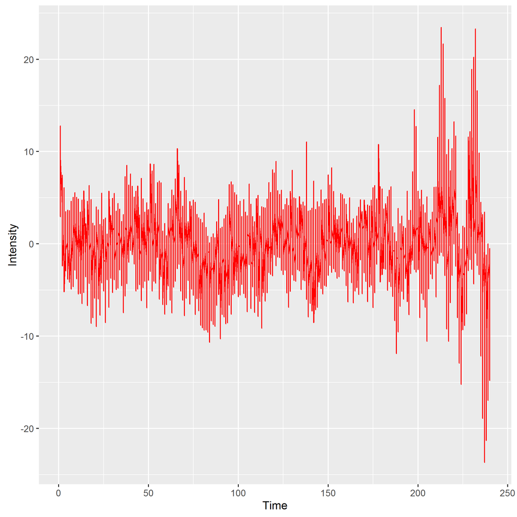

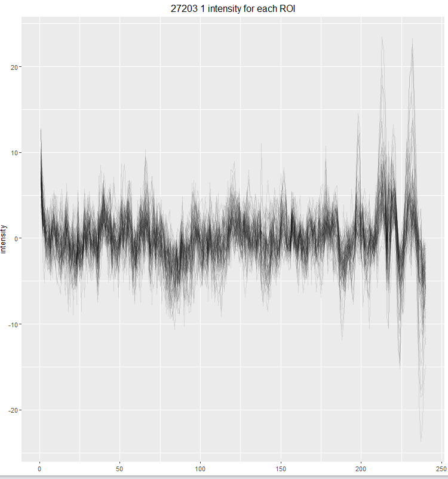

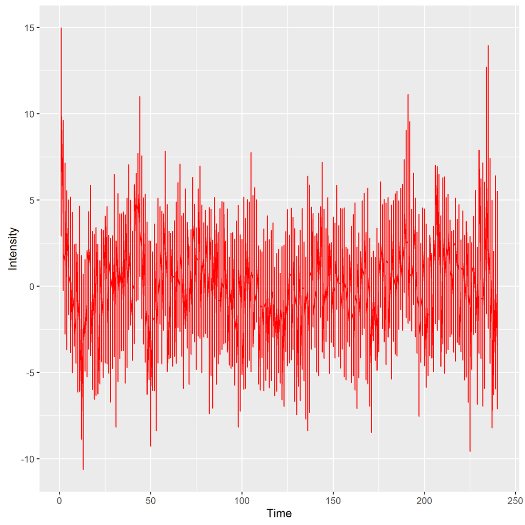

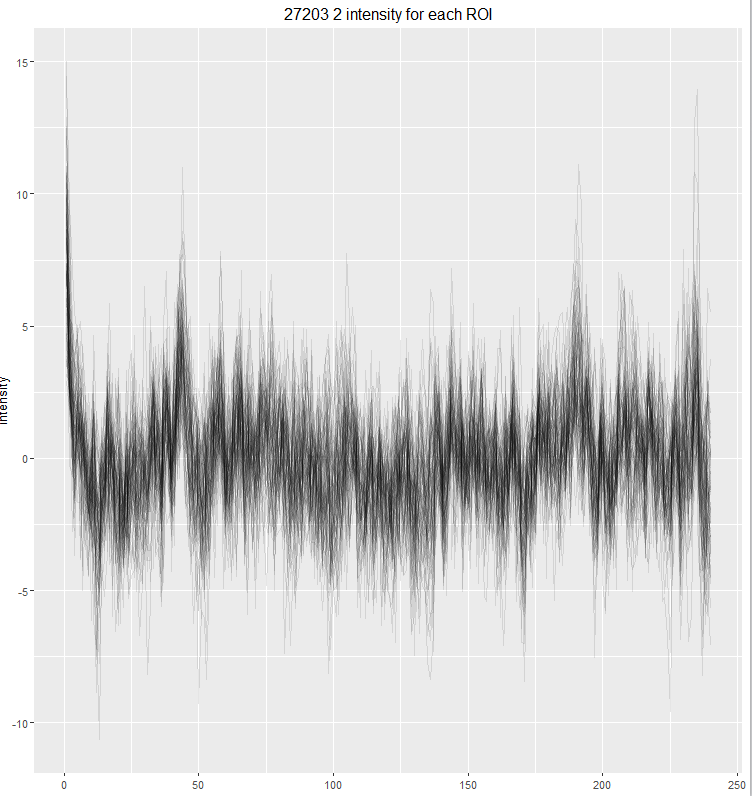

2. For each subject, I produced a correlation coefficient plot that shows the pairwise correlation of the voxels’ intensities. Below is the code used to generate the accompanying plots:

```r
import matplotlib.pylab as plt
import numpy as np
import pandas as pd

fig = plt.figure()
ax = fig.add_subplot(1,1,1)
ax.set_aspect('equal')

#ts = np.load('desikan_2mm/SWU_1_0027203_1_rest_desikan_2mm.npz')
ts = pd.read_csv('desikan_2mm/SWU_1_0027203_1_rest_desikan_2mm.csv', sep=' ', header=None)
#print(ts)
G1 = np.corrcoef(ts)

plt.imshow(G1, interpolation='nearest', cmap=plt.cm.ocean)
plt.colorbar()
ax.set_xlabel('ROI')
ax.set_ylabel('ROI')
#plt.show()
plt.savefig('hello.png')
```

The correlation matrix plots generated by this code are below. The ones in blue are mine, and the ones in orange are Eric’s:

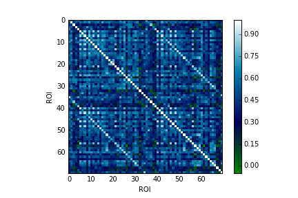

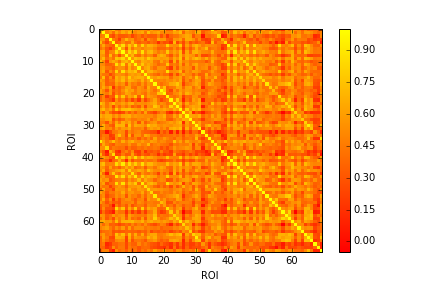

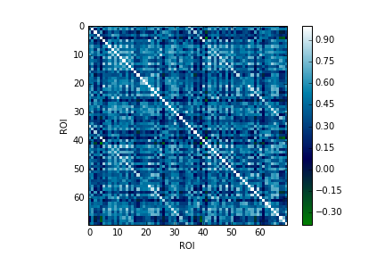

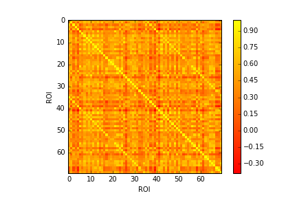

3. The last step was to generate MNR plots that show the intra- and inter-subject distances. This is another way to sanity check our data, because intuitively we know that intra-subject distances should be smaller than inter-subject distances. The code and resulting graphs are below:

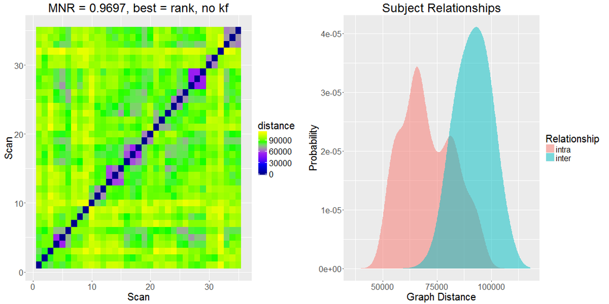

MNR and distances for SWU_1

```r
# an example of a driver that loads timeseries data and produces
# a dataset wide distance estimation (along with mnr) and kde plot
# in a figure
#
# written by Eric Bridgeford

dirn <- dirname(parent.frame(2)$ofile)
dirn <- dirname(sys.frame(1)$ofile)
setwd(dirn)

## Sources ----------------------------------------------------------------------------------------

source('C:/Users/Tanay Agarwal/Desktop/College Classes/NeuroData 1/fngs/data_processing/Rutils/obs2corr.R')
source('C:/Users/Tanay Agarwal/Desktop/College Classes/NeuroData 1/fngs/data_processing/Rutils/open_timeseries.R')
source('C:/Users/Tanay Agarwal/Desktop/College Classes/NeuroData 1/fngs/data_processing/Rutils/obs2zsc.R')
require('ggplot2')
require('reshape2')
require('Rmisc')
require('dlm')
source('C:/Users/Tanay Agarwal/Desktop/College Classes/NeuroData 1/Reliability/Code/FlashRupdated/functions/distance.R')
source('C:/Users/Tanay Agarwal/Desktop/College Classes/NeuroData 1/Reliability/Code/FlashRupdated/functions/reliability.R')
source('C:/Users/Tanay Agarwal/Desktop/College Classes/NeuroData 1/Reliability/Code/FlashRupdated/functions/computerank.R')
source('C:/Users/Tanay Agarwal/Desktop/College Classes/NeuroData 1/Reliability/Code/R/processing/hell_dist.R')
source('C:/Users/Tanay Agarwal/Desktop/College Classes/NeuroData 1/Reliability/Code/R/processing/thresh_mnr.R')
source('C:/Users/Tanay Agarwal/Desktop/College Classes/NeuroData 1/fngs/data_processing/Rutils/obs2kf.R')

#datasets <- c('NKI', 'BNU1', 'BNU2', 'HNU1', 'DC1')
#datasets <- c('NKI', 'BNU1', 'BNU2')
datasets <- c('SWU')
outpath <- 'C:/Users/Tanay Agarwal/Desktop/College Classes/NeuroData 1/Deliverables 10-5/mnr_plots/'
#kfopts <- c('kf', 'no kf')
kfopts <- c('no kf')
#scan_pos <- c(2, 3, 3, 3, 3)
scan_pos <- c(1, 1)
inpath <- 'C:/Users/Tanay Agarwal/Desktop/College Classes/NeuroData 1/Deliverables 10-5/desikan_2mm/'

## Loading Timeseries --------------------------------------------------------------------------------

atlases <- c('desikan_2mm')
for (at in atlases[1]) {
  # dir.create(paste(outpath, at, "/", sep=""))
  for (dataset in datasets) {
    opath <- outpath #paste(outpath, dataset, "/", at, "/", sep="")
    # dir.create(opath)
    tpath <- inpath #paste(inpath, dataset, "/", at, "/", sep="")
    tsnames <- list.files(tpath, pattern="\\.rds", full.names=TRUE)
    #print(tsnames)
    tsobj <- open_timeseries(tsnames, sub_pos=3)
    #print(tsobj)
    ts <- tsobj[[1]]
    sub <- tsobj[[3]]
    #print(sub)
    maxmnr <- 0

    for (opt in kfopts) {
      if (isTRUE(all.equal(opt, 'kf'))) {
        kf <- obs2kf(ts)
        #zsc <- signal2zscore(ts)
        corr <- obs2corr(kf)

      } else {
        #zsc <- signal2zscore(ts)
        corr <- obs2corr(ts)
        #print(ts)
        #corr <- cor(do.call(rbind, ts))
      }

      #print(corr)

      ## Change Convention from preferred vara[[sub]][array] to vara[sub,array] for use with old code ---------
      nroi <- dim(corr[["1"]])[1]
      nscans <- length(corr)
      #print(nroi)
      wgraphs <- array(rep(NaN, nroi*nroi*nscans), c(nroi, nroi, nscans))

      #corr[is.nan(corr)] == 0

      counter <- 1
      for (subject in names(corr)) {
        #print(corr[[subject]])
        wgraphs[,,counter] <- corr[[subject]]
        #wgraphs[counter,,] <- corr[[subject]]
        counter <- counter + 1
      }
      #print(wgraphs[1,,])
      #print(max(wgraphs))

      ## Compute MNR ----------------------------------------------------------------

      thresh_obj <- thresh_mnr(wgraphs, sub, N = 25)

      mnrthresh <- thresh_obj[[1]]
      Dthresh <- thresh_obj[[2]]
      mnrthresh <- 0

      ranked_graphs <- rank_matrices(wgraphs)
      Drank <- distance(ranked_graphs)
      mnrrank <- mnr(rdf(Drank, sub))

      Draw <- distance(wgraphs)
      mnrraw <- mnr(rdf(Draw, sub))
      #print(c(mnrraw, mnrrank, mnrthresh))
      optmax_mnr <- max(c(mnrraw, mnrrank, mnrthresh))
      if (isTRUE(optmax_mnr > maxmnr)) {
        maxmnr <- optmax_mnr
        kfo <- opt
        if (isTRUE(all.equal(maxmnr, mnrraw))) {
          Dmax <- Draw
          winner <- 'raw'
        } else if (isTRUE(all.equal(maxmnr, mnrrank))) {
          Dmax <- Drank
          winner <- 'rank'
        } else {
          Dmax <- Dthresh
          winner <- 'thresh'
        }
      }
    }

    ## Produce Plots for MNR --------------------------------------------------------

    kdeobj <- hell_dist(Dmax, sub)
    kde_dist <- data.frame(kdeobj[[1]]$y, kdeobj[[2]]$y, kdeobj[[1]]$x)
    colnames(kde_dist) <- c("intra", "inter", "Graph Distance")
    meltkde <- melt(kde_dist, id="Graph Distance")
    colnames(meltkde) <- c("Graph Distance", "Relationship", "Probability")


    distance_title <- sprintf('MNR = %.4f, best = %s, %s', maxmnr, winner, kfo)
    distance_plot <- ggplot(melt(Dmax), aes(x=Var1, y=Var2, fill=value)) +
      geom_tile() +
      scale_fill_gradientn(colours=c("darkblue","blue","purple","green","yellow"),name="distance") +
      xlab("Scan") + ylab("Scan") + ggtitle(distance_title) +
      theme(text=element_text(size=20))

    kde_plot <- ggplot()+geom_ribbon(data=meltkde, aes(x=`Graph Distance`, ymax=Probability, fill=Relationship), ymin=0, alpha=0.5) +
      ggtitle("Subject Relationships") + theme(text=element_text(size=20))

    png(paste(outpath, dataset, "_", kfopts, "_", at, ".png", sep=""), height=600, width = 1200)
    multiplot(distance_plot, kde_plot, layout=matrix(c(1,2), nrow=1, byrow=TRUE))
    dev.off()
  }
}
```

Note: There seems to be an issue with some of the data produced by my pipeline runs. The MNR generation code above works when I run it on subjects 0027203:0027214 inclusive, but as soon as I include anything from subjects 0027215:0027222, it breaks. However, the data in those files appears fine based on the correlation matrix and intensity plots. I wasn’t able to get down to the bottom of this due to lack of time, as I spent 10+ hours just narrowing the problem down to specific subject data.